# Project: TMDb Movie Data Analysis

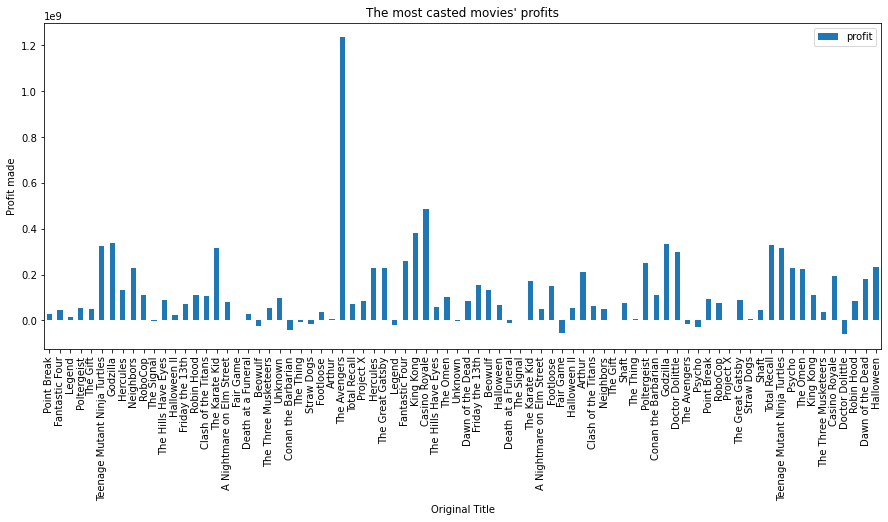

```python
#I'm trying to see how much the top casted movies make or lose
df_og[mask].plot.bar(x='original_title', y='profit',figsize=(15,6),xlabel='Original Title',ylabel='Profit made');
plt.title('The most casted movies\' profits');
```

Generally, I can see that they mostly make a good profit, which is what I was expecting to see.(The avengers set the bar a little bit too high though!)

> Now, how about the votes that large casted movies get:

```python
#Top casted successful movies vote counts vs Top casted failing movies vote counts
df_og[mask].query('success == True')['vote_count'].mean() , df_og[mask].query('success == False')['vote_count'].mean()
```

```
(769.9558823529412, 172.0)
```

```python
#same thing with vote average
df_og[mask].query('success == True')['vote_average'].mean() , df_og[mask].query('success == False')['vote_average'].mean()
```

```
(6.173529411764705, 5.408333333333334)
```

They apparently get more more votes and better votes average.

```python
#Actors in most successful movies
#Reading them into a dataframe
d1= pd.DataFrame(df_artist_og.query('success == True').groupby('cast').nunique().sort_values(by=['original_title'], ascending=False)['original_title'].head(40))
#the dataframe has the actor names as index
d1['actor']= list(d1.index)
d1.rename(columns={'original_title':'hits'}, inplace=True)
#Adding a columns of failed movies from similar top actors
d1['fails']= list(df_artist_og.query('success == False').groupby('cast').nunique().sort_values(by=['original_title'], ascending=False)['original_title'].head(40))
```

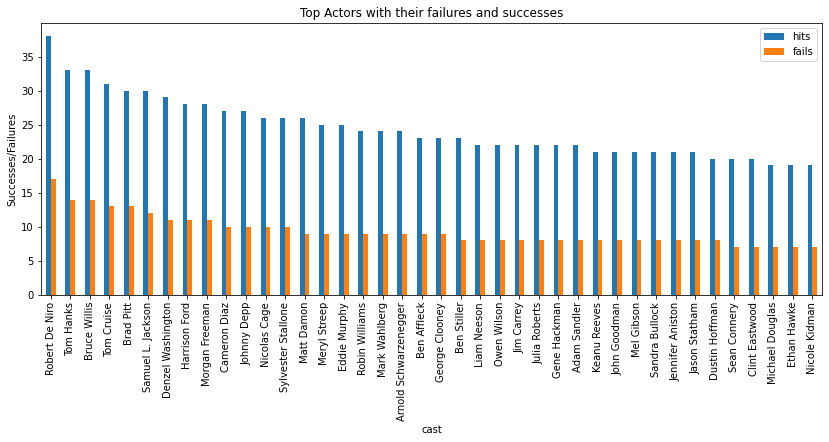

```python
d1.plot(kind='bar',figsize=(14,5), ylabel='Successes/Failures');
plt.title('Top Actors with their failures and successes');
```

I was expecting to see actors in successful movies staying successful all the way, but it doesn't seem to be so. It appears that they may be successful once and the next time not.

> No clear pattern here, but I can see that they have at least a better success rate.

```python
#companies that invested most
df_company_og.query('success == True').sort_values(by=['budget'],ascending=False)[['production_companies', 'budget_adj', 'original_title']].head(40)
```

|  | production_companies | budget_adj | original_title |
| --- | --- | --- | --- |
| 3404 | Jerry Bruckheimer Films | 3.683713e+08 | Pirates of the Caribbean: On Stranger Tides |
| 3403 | Walt Disney Pictures | 3.683713e+08 | Pirates of the Caribbean: On Stranger Tides |
| 3405 | Moving Picture Company (MPC) | 3.683713e+08 | Pirates of the Caribbean: On Stranger Tides |
| 7842 | Jerry Bruckheimer Films | 3.155006e+08 | Pirates of the Caribbean: At World's End |
| 7843 | Second Mate Productions | 3.155006e+08 | Pirates of the Caribbean: At World's End |
| 7841 | Walt Disney Pictures | 3.155006e+08 | Pirates of the Caribbean: At World's End |
| 48 | Marvel Studios | 2.575999e+08 | Avengers: Age of Ultron |
| 49 | Prime Focus | 2.575999e+08 | Avengers: Age of Ultron |
| 50 | Revolution Sun Studios | 2.575999e+08 | Avengers: Age of Ultron |
| 6879 | DC Comics | 2.920507e+08 | Superman Returns |
| 6881 | Warner Bros. | 2.920507e+08 | Superman Returns |
| 6882 | Bad Hat Harry Productions | 2.920507e+08 | Superman Returns |
| 6880 | Legendary Pictures | 2.920507e+08 | Superman Returns |
| 4677 | Walt Disney Pictures | 2.469335e+08 | John Carter |
| 1709 | Walt Disney Animation Studios | 2.600000e+08 | Tangled |
| 1708 | Walt Disney Pictures | 2.600000e+08 | Tangled |
| 7871 | Marvel Enterprises | 2.713305e+08 | Spider-Man 3 |
| 7870 | Laura Ziskin Productions | 2.713305e+08 | Spider-Man 3 |
| 7869 | Columbia Pictures | 2.713305e+08 | Spider-Man 3 |
| 580 | Bad Hat Harry Productions | 2.302728e+08 | X-Men: Days of Future Past |
| 581 | TSG Entertainment | 2.302728e+08 | X-Men: Days of Future Past |
| 578 | Donners' Company | 2.302728e+08 | X-Men: Days of Future Past |
| 4555 | Metro-Goldwyn-Mayer (MGM) | 2.374361e+08 | The Hobbit: An Unexpected Journey |
| 4554 | New Line Cinema | 2.374361e+08 | The Hobbit: An Unexpected Journey |
| 4553 | WingNut Films | 2.374361e+08 | The Hobbit: An Unexpected Journey |
| 1691 | Warner Bros. | 2.500000e+08 | Harry Potter and the Deathly Hallows: Part 1 |
| 4541 | Legendary Pictures | 2.374361e+08 | The Dark Knight Rises |
| 4542 | Warner Bros. | 2.374361e+08 | The Dark Knight Rises |
| 579 | Marvel Entertainment | 2.302728e+08 | X-Men: Days of Future Past |
| 1692 | Heyday Films | 2.500000e+08 | Harry Potter and the Deathly Hallows: Part 1 |
| 577 | Twentieth Century Fox Film Corporation | 2.302728e+08 | X-Men: Days of Future Past |
| 4544 | Syncopy | 2.374361e+08 | The Dark Knight Rises |
| 5636 | Metro-Goldwyn-Mayer (MGM) | 2.340083e+08 | The Hobbit: The Desolation of Smaug |
| 5635 | New Line Cinema | 2.340083e+08 | The Hobbit: The Desolation of Smaug |
| 5634 | WingNut Films | 2.340083e+08 | The Hobbit: The Desolation of Smaug |
| 545 | Metro-Goldwyn-Mayer (MGM) | 2.302728e+08 | The Hobbit: The Battle of the Five Armies |
| 544 | 3Foot7 | 2.302728e+08 | The Hobbit: The Battle of the Five Armies |
| 543 | New Line Cinema | 2.302728e+08 | The Hobbit: The Battle of the Five Armies |
| 542 | WingNut Films | 2.302728e+08 | The Hobbit: The Battle of the Five Armies |
| 1124 | Heyday Films | 2.541001e+08 | Harry Potter and the Half-Blood Prince |

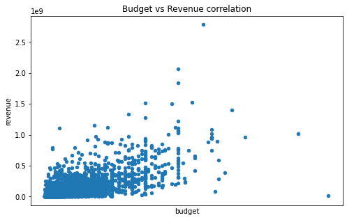

```python
#Does investing much results in a success?
df_og.plot(kind='scatter', x='budget', y='revenue', figsize=(8,5));
plt.xticks([])
plt.title('Budget vs Revenue correlation');
```

It looks like possibly a positive correlation, but I'm not so sure.

^I found some inspiration [here](https://seaborn.pydata.org/tutorial/categorical.html)

### Research Question 2 (Which genres are more likely to succeed?)

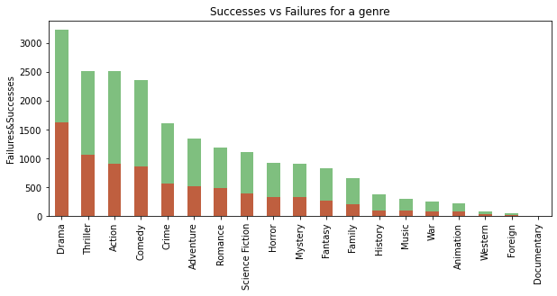

```python
df[successful].genres.value_counts().plot(alpha=0.5, color='green',kind='bar',figsize=(10,5));
df[failed].genres.value_counts().plot(alpha=0.5, color='red',kind='bar',figsize=(10,4),ylabel='Failures&Successes');
plt.title('Successes vs Failures for a genre');
```

I can see here that we have many Dramas in successful movies; maybe a predictor

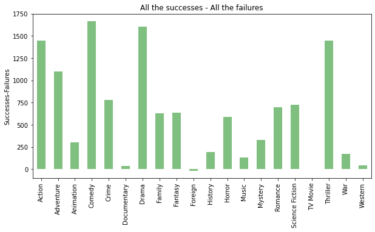

```python
#Average failure per genre
#number of success-number of failures under each genre
#count successes and failures under a genre
((df[successful].genres.value_counts())-(df[failed].genres.value_counts())).plot(alpha=0.5, color='green',x="genres",kind='bar',figsize=(10,5),ylabel='Successes-Failures');
plt.title('All the successes - All the failures');
```

Considering failures and successes under each genre, I can see that some have a high rate of success than others

```python
#Finding out the top genres
df[successful].genres.value_counts()
```

```
Drama              3232
Comedy             2525
Thriller           2514
Action             2357
Adventure          1615
Crime              1346
Romance            1192
Science Fiction    1113
Horror              926
Fantasy             905
Family              834
Mystery             662
Animation           388
History             298
War                 263
Music               223
Western              85
Documentary          52
Foreign               5
TV Movie              3
Name: genres, dtype: int64
```

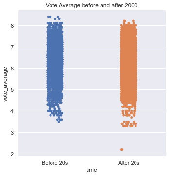

```python
sns.catplot( x="time", y="vote_average", order=["Before 20s", "After 20s"], data=df_company_og).set(title='Vote Average before and after 2000');
```

Is it that some movies were better back then or is it that moviegoers became more hungry for other things?

> Anyway,from what I can see here, there are low rates that are present after the 20s than before it

> And also, a high rate before 20s (it could be maybe 8.5) that no movie after 20s reached

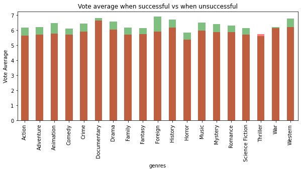

```python
#genres average vote of successful films
df[successful].groupby('genres').mean()['vote_average'].plot.bar(alpha=0.5, color='green', figsize=(10,5));
df[failed].groupby('genres').mean()['vote_average'].plot.bar(alpha=0.5, color='red', figsize=(10,4),ylabel='Vote Average');
plt.title('Vote average when successful vs when unsuccessful');
```

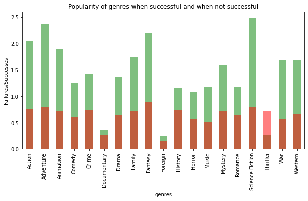

```python
df[successful].groupby('genres').mean()['popularity'].plot.bar(alpha=0.5, color='green', figsize=(10,5));
df[failed].groupby('genres').mean()['popularity'].plot.bar(alpha=0.5, color='red', figsize=(10,5),ylabel='Failures/Successes');
plt.title('Popularity of genres when successful and when not successful');
```

There are some genres like fantasy or science fiction that are popular whelther they succeed or not!

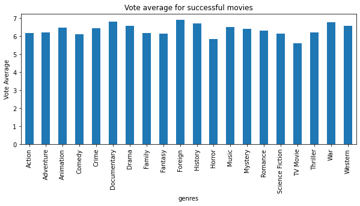

```python
df[successful].groupby('genres').mean()['vote_average'].plot.bar(figsize=(10,4),ylabel='Vote Average');
plt.title('Vote average for successful movies');
```

Some genres like war, foreign, history and documentaries have the best votes average.

> I suppose this is because they play real events that people can relate to easily

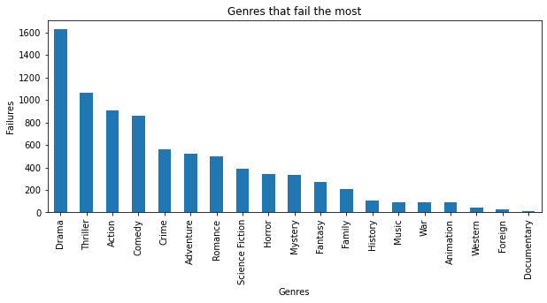

```python
#which genres fail less often?
df[failed].genres.value_counts().plot.bar(figsize=(10,4), ylabel='Failures', xlabel='Genres');
plt.title('Genres that fail the most');
```

Ironically, Dramas are the most successful and unsuccessful genre!

> As I expected, genre isn't a clear factor to know if a movie will succeed or not.

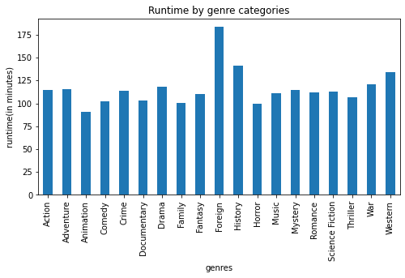

```python
#Trying to find out what genre tend to last longer
df[successful].groupby('genres').runtime.mean().plot.bar(figsize=(8,4),ylabel='runtime(in minutes)');
df[failed].groupby('genres').runtime.mean().plot.bar(figsize=(8,4),ylabel='runtime(in minutes)');
plt.title('Runtime by genre categories');
```

```python
df.groupby(['release_year','genres']).popularity.sum()
```

```
release_year  genres
1960          Action               4.881207
              Adventure            3.744264
              Comedy               2.006256
              Drama                5.641919
              History              1.136943
                                    ...
2015          Romance            118.722936
              Science Fiction    571.066719
              Thriller           683.385439
              War                 39.133846
              Western             63.248700
Name: popularity, Length: 842, dtype: float64
```

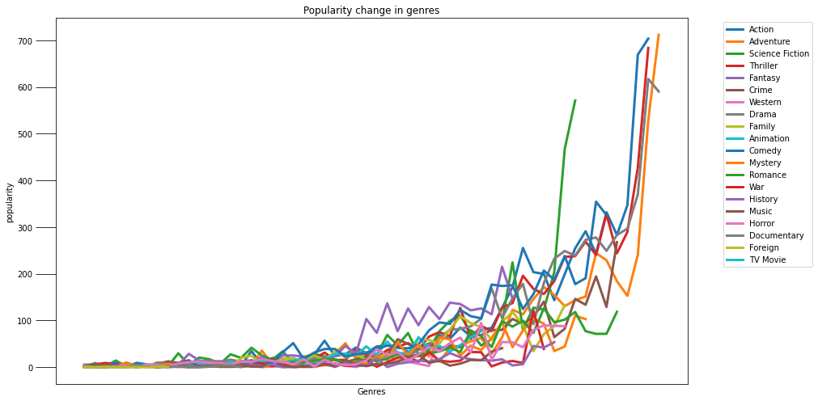

```python
#Trying to see in a clear way how the genres grew popular over the years
for i in df['genres'].unique():
    m= df['genres']== i
    df[m].groupby(['release_year','genres']).popularity.sum().plot(xlabel='Genres',label=i, linewidth=3, figsize=(12,7));
    plt.tight_layout()
    plt.legend(bbox_to_anchor = (1.05, 1))
    plt.ylabel('popularity')
    plt.xticks([])
    plt.title('Popularity change in genres')
    plt.tick_params(axis='y', length=25)
```

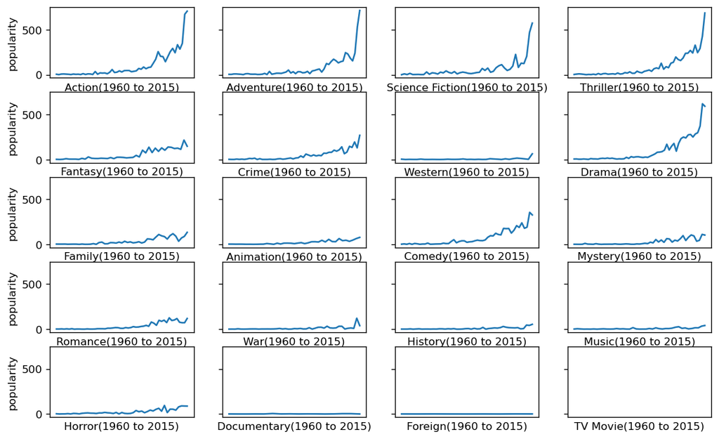

```python
#And individually...
fig, axes = plt.subplots(nrows=5, ncols=4, figsize=(11,7), dpi=120, sharey=True)
l= list(df['genres'].unique())
count=0
for i in range(5):
    for j in range(4):
        m= df['genres']== l[count]
        df[m].groupby(['release_year','genres']).popularity.sum().plot(xlabel=l[count]+'(1960 to 2015)', ylabel='popularity', ax=axes[i,j], xticks=[]);
        count+=1
```

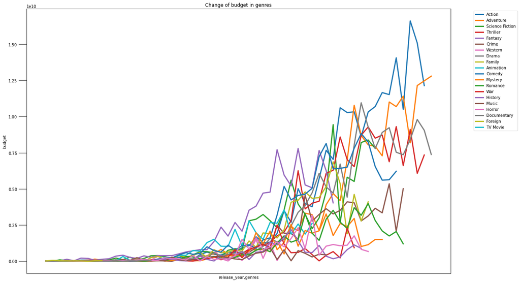

```python
for i in df['genres'].unique():
    m= df['genres']== i
    df[m].groupby(['release_year','genres']).budget.sum().plot(label=i, linewidth=3, figsize=(16,10));
    plt.tight_layout()
    plt.legend(bbox_to_anchor = (1.05, 1))
    plt.ylabel('budget')
    plt.xticks([])
    plt.title('Change of budget in genres')
    plt.tick_params(axis='y', length=20)
```

Companies are investing more in adventures and actions(though a bit less than previous years)

## Conclusions

Many of the conclusions to be made here are difficult because this data set is mostly qualitative than quantitative. Those are limitations of this data set. If the data set included popularity rates for each actor and director, I would explore more the relationship between an actor, a production company, a director and a story line; I think it's where the secret lies when it comes to movies.

Another limitation I have to mention is the fact that I deleted thousands of rows (of empty budget and/or revenue), which may or may not make my findings biased (in successful vs failed movies categories) since most of the deleted rows lied in the failed category.